# Assignment 6

Author

```r
library(tidyverse)
library(ssstats)
library(broom)
```

Dunder Mifflin’s Scranton branch is piloting a new “productivity initiative” designed by Michael Scott. Corporate has asked the analytics team to evaluate whether the initiative is improving performance — or just creating more chaos.

You are given a dataset containing information about employees across several workdays. For each employee-day observation, the dataset includes:

- *meetings*: number of meetings attended that day
- *coffee_cups*: number of cups of coffee consumed
- *dwight_supervision*: whether Dwight directly supervised the employee that day
- *sales_calls*: number of successful sales calls completed in a day
- *incidents*: number of unusual workplace incidents observed per day

0a. Download the data from Canvas and import it to R.

```r
data <- read_csv("https://raw.githubusercontent.com/samanthaseals/SDSII/refs/heads/main/files/data/assignments/week6.csv")
```

**Model 1**

1a. We are interested in modeling the number of incidents observed in a day. Based on the distribution of this outcome, which modeling approach would be most appropriate? Justify your answer.

```r
mean(data$incidents)
```

```
[1] 1.3425
```

```r
var(data$incidents)
```

```
[1] 4.90245
```

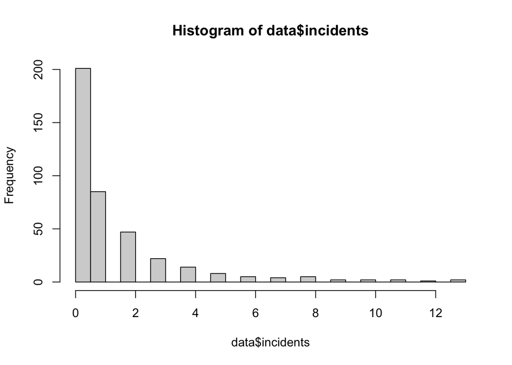

```r
hist(data$incidents, breaks = 20)
```

1b. Fit an appropriate model to predict the number of incidents based on the number of meetings, cups of coffee, and whether Dwight supervised the employee. Call this model `m1`.

```r
m1_nb <- data %>% MASS::glm.nb(incidents ~ meetings + coffee_cups + dwight_supervision, data = .)
m1_nb %>% tidy()
```

| term | estimate | std.error | statistic | p.value |
| --- | --- | --- | --- | --- |
| (Intercept) | -0.71827986 | 0.22295817 | -3.2215902 | 1.274813e-03 |
| meetings | 0.27153455 | 0.04258440 | 6.3763853 | 1.813164e-10 |
| coffee_cups | -0.03159691 | 0.04361014 | -0.7245312 | 4.687397e-01 |
| dwight_supervisionYes | 0.42111519 | 0.15545688 | 2.7088874 | 6.750925e-03 |

```r
m1_poi <- glm(incidents ~ meetings + coffee_cups + dwight_supervision, family = poisson, data = data)
m1_poi %>% tidy()
```

| term | estimate | std.error | statistic | p.value |
| --- | --- | --- | --- | --- |
| (Intercept) | -0.63166180 | 0.13597151 | -4.645545 | 3.391796e-06 |
| meetings | 0.25802153 | 0.02519009 | 10.242978 | 1.272572e-24 |
| coffee_cups | -0.04125933 | 0.02510716 | -1.643330 | 1.003148e-01 |
| dwight_supervisionYes | 0.39661094 | 0.08680315 | 4.569084 | 4.898594e-06 |

1c. Based on your output, state the resulting model.

1d. Is this a significant regression line? You must provide statistical justification for your answer. Assume $\alpha=0.05$.

```r
m1_full <- MASS::glm.nb(incidents ~ meetings + coffee_cups + dwight_supervision, data = data)
m1_reduced <- MASS::glm.nb(incidents ~ 1, data = data)
anova(m1_reduced, m1_full, test = "Chisq")
```

| Model | theta | Resid. df | 2 x log-lik. | Test | df | LR stat. | Pr(Chi) |
| --- | --- | --- | --- | --- | --- | --- | --- |
| 1 | 0.5417867 | 399 | -1256.859 |  | NA | NA | NA |
| meetings + coffee_cups + dwight_supervision | 0.7026539 | 396 | -1211.107 | 1 vs 2 | 3 | 45.7517 | 6.404528e-10 |

```r
m1_nb %>% car::Anova(type = 3)
```

|  | LR Chisq | Df | Pr(>Chisq) |
| --- | --- | --- | --- |
| meetings | 40.6613723 | 1 | 1.810306e-10 |
| coffee_cups | 0.4969273 | 1 | 4.808533e-01 |
| dwight_supervision | 7.4335535 | 1 | 6.401880e-03 |

```r
m1_full <- glm(incidents ~ meetings + coffee_cups + dwight_supervision, family = poisson, data = data)
m1_reduced <- glm(incidents ~ 1, family = poisson, data = data)
anova(m1_reduced, m1_full, test = "Chisq")
```

|  | Resid. Df | Resid. Dev | Df | Deviance | Pr(>Chi) |
| --- | --- | --- | --- | --- | --- |
| 1 | 399 | 1095.5773 | NA | NA | NA |
| 2 | 396 | 956.4116 | 3 | 139.1657 | 5.719213e-30 |

```r
m1_poi %>% car::Anova(type = 3)
```

|  | LR Chisq | Df | Pr(>Chisq) |
| --- | --- | --- | --- |
| meetings | 112.283572 | 1 | 3.096912e-26 |
| coffee_cups | 2.727325 | 1 | 9.864440e-02 |
| dwight_supervision | 20.526377 | 1 | 5.881516e-06 |

1e. Which, if any, are significant predictors of the number of incidents observed? You must provide statistical justification for your answer. Assume $\alpha=0.05$.

```r
m1 %>% car::Anova(type = 3)
```

[output not shown]

1f. Interpret the following effects:

- **number of meetings**:
- **cups of coffee**:
- **Dwight’s supervision**:

1g. Construct a basic visualization to help you explain model results. Clearly state the following:

- What is on the *x*-axis?
- What is on the *y*-axis?
- What will the line(s) represent?

**Model 2**

2a. We are interested in modeling the number of successful calls completed in a day. Based on the distribution of this outcome, which modeling approach would be most appropriate? Justify your answer.

```r
mean(data$sales_calls)
```

```
[1] 7.74
```

```r
var(data$sales_calls)
```

```
[1] 14.37333
```

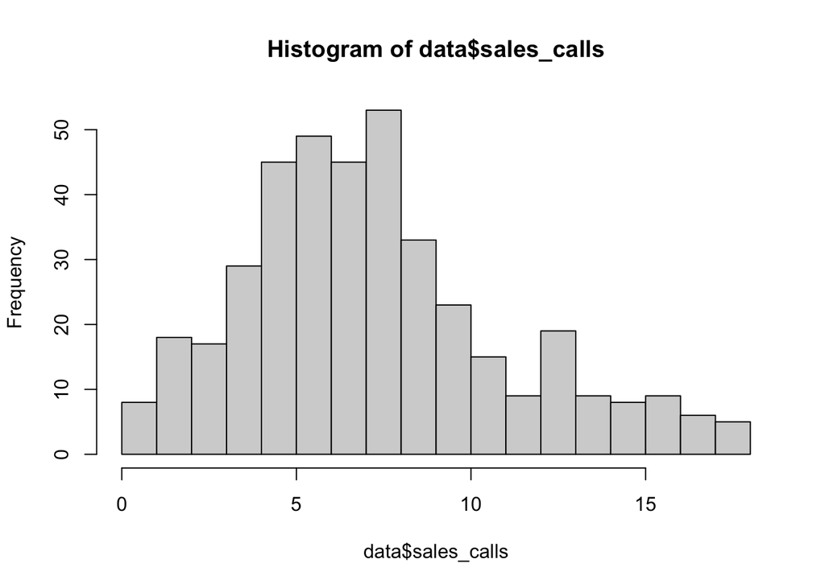

```r
hist(data$sales_calls, breaks = 20)
```

2b. Fit an appropriate model to predict the number of successful calls completed in a day based on the number of meetings, cups of coffee, and whether Dwight supervised the employee. Call this model `m2`.

```r
m2_poi <- data %>% glm(sales_calls ~ meetings + coffee_cups + dwight_supervision, family = "poisson", data = .)
m2_nb <- data %>%
  MASS::glm.nb(sales_calls ~ meetings + coffee_cups + dwight_supervision,
               data = .,
               control = glm.control(maxit = 150))
m2_poi %>% tidy()
```

| term | estimate | std.error | statistic | p.value |
| --- | --- | --- | --- | --- |
| (Intercept) | 1.20788372 | 0.05442273 | 22.194470 | 3.884055e-109 |
| meetings | 0.14467349 | 0.01001736 | 14.442282 | 2.804016e-47 |
| coffee_cups | 0.07499478 | 0.01000453 | 7.496085 | 6.575216e-14 |
| dwight_supervisionYes | 0.32121385 | 0.03625613 | 8.859573 | 8.032124e-19 |

```r
m2_nb %>% tidy()
```

| term | estimate | std.error | statistic | p.value |
| --- | --- | --- | --- | --- |
| (Intercept) | 1.20788372 | 0.05442290 | 22.194404 | 3.889750e-109 |
| meetings | 0.14467349 | 0.01001738 | 14.442248 | 2.805418e-47 |
| coffee_cups | 0.07499478 | 0.01000454 | 7.496072 | 6.575862e-14 |
| dwight_supervisionYes | 0.32121385 | 0.03625620 | 8.859557 | 8.033327e-19 |

2c. Based on your output, state the resulting model.

2d. Is this a significant regression line? You must provide statistical justification for your answer. Assume $\alpha=0.05$.

```r
m2_poi_full <- data %>% glm(sales_calls ~ meetings + coffee_cups + dwight_supervision, family = "poisson", data = .)
m2_poi_reduced <- data %>% glm(sales_calls ~ 1, family = "poisson", data = .)
anova(m2_poi_reduced, m2_poi_full, test = "Chisq")
```

|  | Resid. Df | Resid. Dev | Df | Deviance | Pr(>Chi) |
| --- | --- | --- | --- | --- | --- |
| 1 | 399 | 750.5508 | NA | NA | NA |
| 2 | 396 | 409.0856 | 3 | 341.4652 | 1.051127e-73 |

```r
m2_nb_full <- data %>% MASS::glm.nb(sales_calls ~ meetings + coffee_cups + dwight_supervision, data = ., control = glm.control(maxit = 150))
m2_nb_reduced <- data %>% MASS::glm.nb(sales_calls ~ 1, data = ., control = glm.control(maxit = 150))
anova(m2_poi_reduced, m2_poi_full, test = "Chisq")
```

|  | Resid. Df | Resid. Dev | Df | Deviance | Pr(>Chi) |
| --- | --- | --- | --- | --- | --- |
| 1 | 399 | 750.5508 | NA | NA | NA |
| 2 | 396 | 409.0856 | 3 | 341.4652 | 1.051127e-73 |

2e. Which, if any, are significant predictors of the number of incidents observed? You must provide statistical justification for your answer. Assume $\alpha=0.05$.

```r
m2_poi %>% car::Anova(type = 3)
```

|  | LR Chisq | Df | Pr(>Chisq) |
| --- | --- | --- | --- |
| meetings | 213.22622 | 1 | 2.716573e-48 |
| coffee_cups | 55.35996 | 1 | 1.003600e-13 |
| dwight_supervision | 77.24763 | 1 | 1.508127e-18 |

```r
m2_nb %>% car::Anova(type = 3)
```

|  | LR Chisq | Df | Pr(>Chisq) |
| --- | --- | --- | --- |
| meetings | 203.78053 | 1 | 3.125172e-46 |
| coffee_cups | 78.54484 | 1 | 7.820285e-19 |
| dwight_supervision | 63.50844 | 1 | 1.596814e-15 |

2f. Interpret the following effects:

- **number of meetings**:
- **cups of coffee**:
- **Dwight’s supervision**:

2g. Construct a basic visualization to help you explain model results. Clearly state the following:

- What is on the *x*-axis?
- What is on the *y*-axis?
- What will the line(s) represent?

**Summary**

3. Pick either `m1` or `m2` and summarize your findings for Michael. Be sure to include interpretations of the predictors, significance of the model, and any visualizations you created.

**Exploration Time!**

4a. Re-fit `m1` using the normal distribution and examine relevant statistical inference. How different are the results?

4b. Check the assumptions on the normal distribution. Remember to draw a conclusion.

4c. Re-fit `m2` using the normal distribution and examine relevant statistical inference. How different are the results?

4d. Check the assumptions on the normal distribution. Remember to draw a conclusion.

**Research Time!**

This section is a **bonus** section for undergraduate students, but a **required** section for graduate students.

5a. What are the zero-inflated Poisson and zero-inflated negative binomial models? When are they appropriate to employ?

5b. Why aren’t the zero-inflated models appropriate for this dataset? What would have to be different about the data for these models to be appropriate?